# Lesson 151 · Portfolio entry 1: entity classification

Teacher solution · PROVIDED / TODO / CHECK / EXIT. Tier B: full relational task. Three live functions select, summarize and bound the claim. Default execution independently audits saved author evidence; the full GPU gate runs all thirteen fresh fits.

```python
# @colab-bootstrap — default CPU evidence audit; full training is explicitly gated.
import os,sys,subprocess
os.environ.update(OMP_NUM_THREADS='1',OPENBLAS_NUM_THREADS='1',MKL_NUM_THREADS='1')
if 'google.colab' in sys.modules:
    subprocess.check_call([sys.executable,'-m','pip','install','-q','pytorch-frame==0.2.3','torch-geometric==2.6.1','relbench==1.1.0','sentence-transformers==3.3.1'])
from pathlib import Path
import base64,hashlib,io,json,zlib,math,statistics
import numpy as np,pandas as pd
from IPython.display import display
RUN_FULL_REPRODUCTION=False
VALIDATE_ONE=False;PREPARED_ROOT=None
```

```python
# PROVIDED: label/key/rank helpers
"""Load-bearing clinical-trial contracts. Times use one consistent unit."""
import numpy as np

def trial_target(start,analyses,cutoff,horizon=365):
    """Return (eligible, label); match released SQL, including modifier quirks."""
    if not np.isfinite(start) or not np.isfinite(cutoff) or horizon<=0:
        raise ValueError('finite start/cutoff and positive horizon required')
    if start>cutoff:return False,None
    values=[]
    for date,p,modifier,kind in analyses:
        if (kind=='Primary' and modifier!='>' and p is not None
                and 0<=p<=1 and cutoff<date<=cutoff+horizon):
            values.append(p)
    return (True,int(min(values)<=.05)) if values else (False,None)

def visibility_mask(times,owners,cutoffs):
    """Every sampled node inherits its own query cutoff, never a batch maximum."""
    times=np.asarray(times);owners=np.asarray(owners);cutoffs=np.asarray(cutoffs)
    if any(a.ndim!=1 for a in [times,owners,cutoffs]) or len(times)!=len(owners):
        raise ValueError('one time and owner per node required')
    if not np.isfinite(times).all() or not np.isfinite(cutoffs).all():
        raise ValueError('nonfinite temporal values')
    if len(owners) and (not np.issubdtype(owners.dtype,np.integer) or owners.min()<0 or owners.max()>=len(cutoffs)):
        raise ValueError('invalid query ownership')
    return times<=cutoffs[owners.astype(int)]

def keyed_auc(query_keys,targets,prediction_keys,scores):
    """Align complete unique (entity, cutoff) keys, then count tied rank wins."""
    q=[tuple(k) for k in query_keys];p=[tuple(k) for k in prediction_keys]
    if len(set(q))!=len(q) or len(set(p))!=len(p) or set(q)!=set(p):
        raise ValueError('keys must be unique and cover exactly the same queries')
    if len(targets)!=len(q) or len(scores)!=len(p):raise ValueError('length mismatch')
    mapping=dict(zip(p,scores));return rank_auc(targets,[mapping[k] for k in q])

def rank_auc(target,scores):
    """Positive-negative concordance with half credit for ties; O(n log n)."""
    y=np.asarray(target);s=np.asarray(scores,dtype=float)
    if y.ndim!=1 or s.shape!=y.shape or not np.isfinite(s).all() or not np.isin(y,[0,1]).all():
        raise ValueError('Aligned binary labels and finite scores required')
    positives=int(y.sum());negatives=len(y)-positives
    if positives==0 or negatives==0:raise ValueError('Both classes required')
    order=np.argsort(s,kind='stable');s=s[order];y=y[order]
    starts=np.r_[0,1+np.flatnonzero(s[1:]!=s[:-1])];ends=np.r_[starts[1:],len(s)]
    group_pos=np.add.reduceat(y,starts);group_neg=ends-starts-group_pos
    lower_neg=np.cumsum(group_neg)-group_neg
    return float(np.sum(group_pos*(lower_neg+.5*group_neg))/(positives*negatives))
```

From a reproduction checkpoint to a reusable research result

**Reading route.** Define the entry → trace a prediction → freeze selection → measure variation → defend the claim.

**Your tangible win:** produce one entity-classification portfolio entry that another researcher can regenerate and challenge. The core reading takes about 15 minutes; the lab and written defense are separate practice.

[Lesson 150](https://avistian.github.io/relational/lessons/0150-q3-reproduction-checkpoint.html) separated protocol, score, competition and learner defense. It left a practical question: what must travel with a result when you place it beside two other tasks? This lesson makes that report reusable. [Lesson 139](https://avistian.github.io/relational/lessons/0139-healthcare-trial.html) supplies the clinical-trial task; here you own the selection and reporting contract.

**Read first:** [RelBench v1 §5.1, Table 6 and Appendix B.2](https://arxiv.org/html/2407.20060v1#A2). Consult the [pinned implementation](https://github.com/snap-stanford/relbench/tree/9aa346267c2e1c560bd92da07d6f4ad1ca2f0639). The named reproduction is the RDL `rel-trial/study-outcome` entry, not the entire benchmark.

## 1 · Decide what the entry means

> **In plain terms.** A portfolio entry is a result plus the instructions and evidence needed to interpret it. A score without those attachments cannot support your thesis.

An **entity-classification task** assigns a binary label to one database entity at a prediction time. Here the entity is a clinical study. A **query key** is `(study_id, cutoff)`: the same study at another cutoff is another prediction problem. The metric is **AUROC**, the probability that a random positive receives a higher score than a random negative, with half credit for ties. Higher is better.

Record six things together: task and population; pinned model/data/runtime; selection rule and budget; every seed and summary; verification artifacts; and a claim with its limits. The [entry template](https://avistian.github.io/relational/labs/l151-entry-template.md) gives these fields a stable home for Lessons 152–154.

**Worked example.** Three positive-negative pairs are wins and one is a tie. Their AUROC is `(3 + 0.5) / 4 = 0.875`. This is a ranking statement, not a statement that predicted probabilities are calibrated. Keep the raw metric in `[0,1]`; multiply by 100 only for a table labeled percentage points.

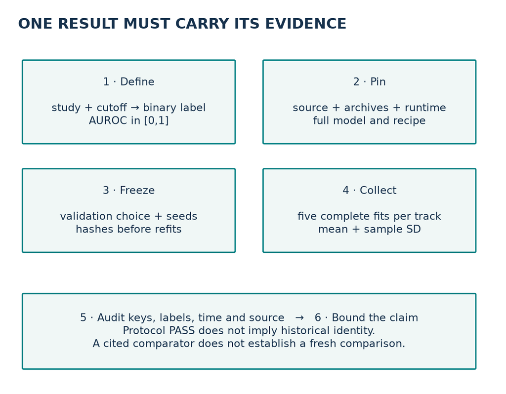

Six entry fields keep the measured result attached to its procedure, audits and claim. Scroll horizontally on narrow screens.

## 2 · Trace what one prediction can know

A **primary outcome** is a study’s designated main measurement. A **p-value** describes how extreme the observed statistic would be under a specified null model; it is not the probability that a treatment works. A modifier such as `>` qualifies a reported numeric value.

The released label asks whether a study has a qualifying primary-outcome analysis in `(cutoff, cutoff + 365 days]`, with a minimum numeric p-value at most `0.05`. A study must have started by the cutoff. A study with no qualifying analysis is absent from the query population, not automatically negative. The release excludes the `>` modifier and preserves its numeric treatment of other modifiers. These are benchmark labels, not clinical recommendations. [Task source](https://github.com/snap-stanford/relbench/blob/9aa346267c2e1c560bd92da07d6f4ad1ca2f0639/relbench/tasks/trial.py)

> **In plain terms.** The label looks forward to define what you are trying to predict. The input must respect what the model could see at the query cutoff.

**Architecture vocabulary.** A **foreign key** links a row to an identified row in another table. An **encoder** converts a row into a learned numerical vector; 128 channels means 128 numbers per row. **GraphSAGE** updates that vector using neighboring rows, separately for each relation type here. The **root** is the study being predicted. The diagram’s **MLP** is a small feed-forward neural network, **ReLU** replaces negative values with zero, and **batch normalization** rescales intermediate features using batch statistics during training.

The full pipeline builds row nodes and foreign-key edges, encodes row features, adds relative-time information, samples two temporal neighborhoods, and predicts one logit for each root study. A **logit** is the unbounded score before the sigmoid maps it into `[0,1]`. Training uses binary cross-entropy on logits. The notebook shows the row encoder, heterogeneous GraphSAGE operations, root readout and training loop inline.

[figure not shown]

Released RDL pipeline, including a worked one-coordinate temporal mean. Illustrative arithmetic is not a measured learned activation. Scroll horizontally on narrow screens.

**Read the scalar trace.** Legal neighbor values 2 and 6 average to 4. The dated neighbor with value 20 is excluded by this query’s cutoff. This illustrates one aggregation coordinate, not the complete learned layer. A **fanout** limits how many neighbors are sampled at a hop; **Adam** updates model weights using gradients, and binary cross-entropy penalizes disagreement with the binary label.

The trial-specific recipe uses two 128-channel layers, mean aggregation within each edge type, summed relation outputs, fanouts 64 then 32, batch size 512, Adam at `0.0001`, and 20 epochs. An **epoch** here traverses all 11,994 training queries. Validation has 960 queries and test has 825. Each sampled timestamp is checked against its owning query cutoff, including when a batch contains different cutoffs. [Appendix B.2](https://arxiv.org/html/2407.20060v1#A2.SS2)

> **Scope check.** The released cohort is retrospective, several dates are inferred, and untimestamped metadata lacks historical arrival records. Source preprocessing uses the released snapshot statistics. Passing event-time checks does not establish feature-arrival legality. Fresh preprocessing does not recover the authors' historical random state.

```python
# PROVIDED: inspect this pipeline stage.
"""Visible RDL blueprint and released-protocol model (RelBench MIT license).

The three learner tasks are deliberately usable with only NumPy. The full
experiment uses pinned PyTorch Frame / PyG primitives, not a hidden model wrapper.
"""
```

```
'Visible RDL blueprint and released-protocol model (RelBench MIT license).\n\nThe three learner tasks are deliberately usable with only NumPy. The full\nexperiment uses pinned PyTorch Frame / PyG primitives, not a hidden model wrapper.\n'
```

```python
# PROVIDED: inspect this pipeline stage.
# %% Key identities (PROVIDED)
import numpy as np
```

```python
# PROVIDED: inspect this pipeline stage.
# %% Task 1: map foreign keys to row positions

def foreign_key_edges(primary_keys, foreign_keys):
    lookup = {key: i for i, key in enumerate(primary_keys)}
    if len(lookup) != len(primary_keys):
        raise ValueError("Primary keys must be unique")
    pairs = []
    for source, key in enumerate(foreign_keys):
        if key is None or (isinstance(key, float) and np.isnan(key)):
            continue
        if key not in lookup:
            raise ValueError("Unknown foreign key")
        pairs.append((source, lookup[key]))
    return np.asarray(pairs, dtype=np.int64).reshape(-1, 2).T
```

```python
# PROVIDED: inspect this pipeline stage.
# %% Task 2: preserve one query cutoff across every hop

def temporal_nodes(edges, times, seed, cutoff, hops):
    if times[seed] is not None and times[seed] > cutoff:
        raise ValueError("Seed is unavailable at the query time")
    seen, frontier = {seed}, {seed}
    for _ in range(hops):
        candidates = {dst for src, dst in edges if src in frontier
                      and (times[dst] is None or times[dst] <= cutoff)}
        frontier = candidates - seen
        seen |= candidates
    return sorted(seen)
```

```python
# PROVIDED: inspect this pipeline stage.
# %% Task 3: attach labels by query identity, not entity identity

def query_targets(targets, input_id):
    return np.asarray(targets)[np.asarray(input_id, dtype=np.int64)]
```

```python
# PROVIDED: inspect this pipeline stage.
# %% Full released model dependencies (PROVIDED)
from typing import Any, Dict, List, Optional

import torch
import torch_frame
from torch import Tensor
from torch_frame.data.stats import StatType
from torch_frame.nn.models import ResNet
from torch_geometric.nn import HeteroConv, LayerNorm, PositionalEncoding, SAGEConv
from torch_geometric.typing import EdgeType, NodeType


class HeteroEncoder(torch.nn.Module):
    r"""HeteroEncoder based on PyTorch Frame.

    Args:
        channels (int): The output channels for each node type.
        node_to_col_names_dict (Dict[NodeType, Dict[torch_frame.stype, List[str]]]):
            A dictionary mapping from node type to column names dictionary
            compatible to PyTorch Frame.
        torch_frame_model_cls: Model class for PyTorch Frame. The class object
            takes :class:`TensorFrame` object as input and outputs
            :obj:`channels`-dimensional embeddings. Default to
            :class:`torch_frame.nn.ResNet`.
        torch_frame_model_kwargs (Dict[str, Any]): Keyword arguments for
            :class:`torch_frame_model_cls` class. Default keyword argument is
            set specific for :class:`torch_frame.nn.ResNet`. Expect it to
            be changed for different :class:`torch_frame_model_cls`.
        default_stype_encoder_cls_kwargs (Dict[torch_frame.stype, Any]):
            A dictionary mapping from :obj:`torch_frame.stype` object into a
            tuple specifying :class:`torch_frame.nn.StypeEncoder` class and its
            keyword arguments :obj:`kwargs`.
    """

    def __init__(
        self,
        channels: int,
        node_to_col_names_dict: Dict[NodeType, Dict[torch_frame.stype, List[str]]],
        node_to_col_stats: Dict[NodeType, Dict[str, Dict[StatType, Any]]],
        torch_frame_model_cls=ResNet,
        torch_frame_model_kwargs: Dict[str, Any] = {
            "channels": 128,
            "num_layers": 4,
        },
        default_stype_encoder_cls_kwargs: Dict[torch_frame.stype, Any] = {
            torch_frame.categorical: (torch_frame.nn.EmbeddingEncoder, {}),
            torch_frame.numerical: (torch_frame.nn.LinearEncoder, {}),
            torch_frame.multicategorical: (
                torch_frame.nn.MultiCategoricalEmbeddingEncoder,
                {},
            ),
            torch_frame.embedding: (torch_frame.nn.LinearEmbeddingEncoder, {}),
            torch_frame.timestamp: (torch_frame.nn.TimestampEncoder, {}),
        },
    ):
        super().__init__()

        self.encoders = torch.nn.ModuleDict()

        for node_type in node_to_col_names_dict.keys():
            stype_encoder_dict = {
                stype: default_stype_encoder_cls_kwargs[stype][0](
                    **default_stype_encoder_cls_kwargs[stype][1]
                )
                for stype in node_to_col_names_dict[node_type].keys()
            }
            torch_frame_model = torch_frame_model_cls(
                **torch_frame_model_kwargs,
                out_channels=channels,
                col_stats=node_to_col_stats[node_type],
                col_names_dict=node_to_col_names_dict[node_type],
                stype_encoder_dict=stype_encoder_dict,
            )
            self.encoders[node_type] = torch_frame_model

    def reset_parameters(self):
        for encoder in self.encoders.values():
            encoder.reset_parameters()

    def forward(
        self,
        tf_dict: Dict[NodeType, torch_frame.TensorFrame],
    ) -> Dict[NodeType, Tensor]:
        x_dict = {
            node_type: self.encoders[node_type](tf) for node_type, tf in tf_dict.items()
        }
        return x_dict


class HeteroTemporalEncoder(torch.nn.Module):
    def __init__(self, node_types: List[NodeType], channels: int):
        super().__init__()

        self.encoder_dict = torch.nn.ModuleDict(
            {node_type: PositionalEncoding(channels) for node_type in node_types}
        )
        self.lin_dict = torch.nn.ModuleDict(
            {node_type: torch.nn.Linear(channels, channels) for node_type in node_types}
        )

    def reset_parameters(self):
        for encoder in self.encoder_dict.values():
            encoder.reset_parameters()
        for lin in self.lin_dict.values():
            lin.reset_parameters()

    def forward(
        self,
        seed_time: Tensor,
        time_dict: Dict[NodeType, Tensor],
        batch_dict: Dict[NodeType, Tensor],
    ) -> Dict[NodeType, Tensor]:
        out_dict: Dict[NodeType, Tensor] = {}

        for node_type, time in time_dict.items():
            rel_time = seed_time[batch_dict[node_type]] - time
            rel_time = rel_time / (60 * 60 * 24)  # Convert seconds to days.

            x = self.encoder_dict[node_type](rel_time)
            x = self.lin_dict[node_type](x)
            out_dict[node_type] = x

        return out_dict


class HeteroGraphSAGE(torch.nn.Module):
    def __init__(
        self,
        node_types: List[NodeType],
        edge_types: List[EdgeType],
        channels: int,
        aggr: str = "mean",
        num_layers: int = 2,
    ):
        super().__init__()

        self.convs = torch.nn.ModuleList()
        for _ in range(num_layers):
            conv = HeteroConv(
                {
                    edge_type: SAGEConv((channels, channels), channels, aggr=aggr)
                    for edge_type in edge_types
                },
                aggr="sum",
            )
            self.convs.append(conv)

        self.norms = torch.nn.ModuleList()
        for _ in range(num_layers):
            norm_dict = torch.nn.ModuleDict()
            for node_type in node_types:
                norm_dict[node_type] = LayerNorm(channels, mode="node")
            self.norms.append(norm_dict)

    def reset_parameters(self):
        for conv in self.convs:
            conv.reset_parameters()
        for norm_dict in self.norms:
            for norm in norm_dict.values():
                norm.reset_parameters()

    def forward(
        self,
        x_dict: Dict[NodeType, Tensor],
        edge_index_dict: Dict[NodeType, Tensor],
        num_sampled_nodes_dict: Optional[Dict[NodeType, List[int]]] = None,
        num_sampled_edges_dict: Optional[Dict[EdgeType, List[int]]] = None,
    ) -> Dict[NodeType, Tensor]:
        for _, (conv, norm_dict) in enumerate(zip(self.convs, self.norms)):
            x_dict = conv(x_dict, edge_index_dict)
            x_dict = {key: norm_dict[key](x) for key, x in x_dict.items()}
            x_dict = {key: x.relu() for key, x in x_dict.items()}

        return x_dict
```

```python
# PROVIDED: inspect this pipeline stage.
# %% Relational node predictor (PROVIDED)
from typing import Any, Dict, List

import torch
from torch import Tensor
from torch.nn import Embedding, ModuleDict
from torch_frame.data.stats import StatType
from torch_geometric.data import HeteroData
from torch_geometric.nn import MLP
from torch_geometric.typing import NodeType




class Model(torch.nn.Module):

    def __init__(
        self,
        data: HeteroData,
        col_stats_dict: Dict[str, Dict[str, Dict[StatType, Any]]],
        num_layers: int,
        channels: int,
        out_channels: int,
        aggr: str,
        norm: str,
        # List of node types to add shallow embeddings to input
        shallow_list: List[NodeType] = [],
        # ID awareness
        id_awareness: bool = False,
    ):
        super().__init__()

        self.encoder = HeteroEncoder(
            channels=channels,
            node_to_col_names_dict={
                node_type: data[node_type].tf.col_names_dict
                for node_type in data.node_types
            },
            node_to_col_stats=col_stats_dict,
        )
        self.temporal_encoder = HeteroTemporalEncoder(
            node_types=[
                node_type for node_type in data.node_types if "time" in data[node_type]
            ],
            channels=channels,
        )
        self.gnn = HeteroGraphSAGE(
            node_types=data.node_types,
            edge_types=data.edge_types,
            channels=channels,
            aggr=aggr,
            num_layers=num_layers,
        )
        self.head = MLP(
            channels,
            out_channels=out_channels,
            norm=norm,
            num_layers=1,
        )
        self.embedding_dict = ModuleDict(
            {
                node: Embedding(data.num_nodes_dict[node], channels)
                for node in shallow_list
            }
        )

        self.id_awareness_emb = None
        if id_awareness:
            self.id_awareness_emb = torch.nn.Embedding(1, channels)
        self.reset_parameters()

    def reset_parameters(self):
        self.encoder.reset_parameters()
        self.temporal_encoder.reset_parameters()
        self.gnn.reset_parameters()
        self.head.reset_parameters()
        for embedding in self.embedding_dict.values():
            torch.nn.init.normal_(embedding.weight, std=0.1)
        if self.id_awareness_emb is not None:
            self.id_awareness_emb.reset_parameters()

    def forward(
        self,
        batch: HeteroData,
        entity_table: NodeType,
    ) -> Tensor:
        seed_time = batch[entity_table].seed_time
        x_dict = self.encoder(batch.tf_dict)

        rel_time_dict = self.temporal_encoder(
            seed_time, batch.time_dict, batch.batch_dict
        )

        for node_type, rel_time in rel_time_dict.items():
            x_dict[node_type] = x_dict[node_type] + rel_time

        for node_type, embedding in self.embedding_dict.items():
            x_dict[node_type] = x_dict[node_type] + embedding(batch[node_type].n_id)

        x_dict = self.gnn(
            x_dict,
            batch.edge_index_dict,
            batch.num_sampled_nodes_dict,
            batch.num_sampled_edges_dict,
        )

        return self.head(x_dict[entity_table][: seed_time.size(0)])
```

```python
# PROVIDED: inspect this pipeline stage.
# %% Full database to REG and query transform (PROVIDED)
import os
from typing import Any, Dict, NamedTuple, Optional, Tuple

import numpy as np
import pandas as pd
import torch
from torch import Tensor
from torch_frame import stype
from torch_frame.config import TextEmbedderConfig
from torch_frame.data import Dataset
from torch_frame.data.stats import StatType
from torch_geometric.data import HeteroData
from torch_geometric.typing import NodeType
from torch_geometric.utils import sort_edge_index

from relbench.base import Database, EntityTask, RecommendationTask, Table, TaskType
from relbench.modeling.utils import remove_pkey_fkey, to_unix_time


def make_pkey_fkey_graph(
    db: Database,
    col_to_stype_dict: Dict[str, Dict[str, stype]],
    text_embedder_cfg: Optional[TextEmbedderConfig] = None,
    cache_dir: Optional[str] = None,
) -> Tuple[HeteroData, Dict[str, Dict[str, Dict[StatType, Any]]]]:
    r"""Given a :class:`Database` object, construct a heterogeneous graph with primary-
    foreign key relationships, together with the column stats of each table.

    Args:
        db: A database object containing a set of tables.
        col_to_stype_dict: Column to stype for
            each table.
        text_embedder_cfg: Text embedder config.
        cache_dir: A directory for storing materialized tensor
            frames. If specified, we will either cache the file or use the
            cached file. If not specified, we will not use cached file and
            re-process everything from scratch without saving the cache.

    Returns:
        HeteroData: The heterogeneous :class:`PyG` object with
            :class:`TensorFrame` feature.
    """
    data = HeteroData()
    col_stats_dict = dict()
    if cache_dir is not None:
        os.makedirs(cache_dir, exist_ok=True)

    for table_name, table in db.table_dict.items():
        # Materialize the tables into tensor frames:
        df = table.df
        # Ensure that pkey is consecutive.
        if table.pkey_col is not None:
            assert (df[table.pkey_col].values == np.arange(len(df))).all()

        col_to_stype = col_to_stype_dict[table_name]

        # Remove pkey, fkey columns since they will not be used as input
        # feature.
        remove_pkey_fkey(col_to_stype, table)

        if len(col_to_stype) == 0:  # Add constant feature in case df is empty:
            col_to_stype = {"__const__": stype.numerical}
            # We need to add edges later, so we need to also keep the fkeys
            fkey_dict = {key: df[key] for key in table.fkey_col_to_pkey_table}
            df = pd.DataFrame({"__const__": np.ones(len(table.df)), **fkey_dict})

        path = (
            None if cache_dir is None else os.path.join(cache_dir, f"{table_name}.pt")
        )

        dataset = Dataset(
            df=df,
            col_to_stype=col_to_stype,
            col_to_text_embedder_cfg=text_embedder_cfg,
        ).materialize(path=path)

        data[table_name].tf = dataset.tensor_frame
        col_stats_dict[table_name] = dataset.col_stats

        # Add time attribute:
        if table.time_col is not None:
            data[table_name].time = torch.from_numpy(
                to_unix_time(table.df[table.time_col])
            )

        # Add edges:
        for fkey_name, pkey_table_name in table.fkey_col_to_pkey_table.items():
            pkey_index = df[fkey_name]
            # Filter out dangling foreign keys
            mask = ~pkey_index.isna()
            fkey_index = torch.arange(len(pkey_index))
            # Filter dangling foreign keys:
            pkey_index = torch.from_numpy(pkey_index[mask].astype(int).values)
            fkey_index = fkey_index[torch.from_numpy(mask.values)]
            # Ensure no dangling fkeys
            assert (pkey_index < len(db.table_dict[pkey_table_name])).all()

            # fkey -> pkey edges
            edge_index = torch.stack([fkey_index, pkey_index], dim=0)
            edge_type = (table_name, f"f2p_{fkey_name}", pkey_table_name)
            data[edge_type].edge_index = sort_edge_index(edge_index)

            # pkey -> fkey edges.
            # "rev_" is added so that PyG loader recognizes the reverse edges
            edge_index = torch.stack([pkey_index, fkey_index], dim=0)
            edge_type = (pkey_table_name, f"rev_f2p_{fkey_name}", table_name)
            data[edge_type].edge_index = sort_edge_index(edge_index)

    data.validate()

    return data, col_stats_dict


class AttachTargetTransform:
    r"""Attach the target label to the heterogeneous mini-batch.

    The batch consists of disjoins subgraphs loaded via temporal sampling. The same
    input node can occur multiple times with different timestamps, and thus different
    subgraphs and labels. Hence labels cannot be stored in the graph object directly,
    and must be attached to the batch after the batch is created.
    """

    def __init__(self, entity: str, target: Tensor):
        self.entity = entity
        self.target = target

    def __call__(self, batch: HeteroData) -> HeteroData:
        batch[self.entity].y = self.target[batch[self.entity].input_id]
        return batch


class NodeTrainTableInput(NamedTuple):
    r"""Training table input for node prediction.

    - nodes is a Tensor of node indices.
    - time is a Tensor of node timestamps.
    - target is a Tensor of node labels.
    - transform attaches the target to the batch.
    """

    nodes: Tuple[NodeType, Tensor]
    time: Optional[Tensor]
    target: Optional[Tensor]
    transform: Optional[AttachTargetTransform]


def get_node_train_table_input(
    table: Table,
    task: EntityTask,
) -> NodeTrainTableInput:
    r"""Get the training table input for node prediction."""

    nodes = torch.from_numpy(table.df[task.entity_col].astype(int).values)

    time: Optional[Tensor] = None
    if table.time_col is not None:
        time = torch.from_numpy(to_unix_time(table.df[table.time_col]))

    target: Optional[Tensor] = None
    transform: Optional[AttachTargetTransform] = None
    if task.target_col in table.df:
        target_type = float
        if task.task_type == TaskType.MULTICLASS_CLASSIFICATION:
            target_type = int
        if task.task_type == TaskType.MULTILABEL_CLASSIFICATION:
            target = torch.from_numpy(np.stack(table.df[task.target_col].values))
        else:
            target = torch.from_numpy(
                table.df[task.target_col].values.astype(target_type)
            )
        transform = AttachTargetTransform(task.entity_table, target)

    return NodeTrainTableInput(
        nodes=(task.entity_table, nodes),
        time=time,
        target=target,
        transform=transform,
    )
```